# Nursing Mental Health

```r
#libraries
library(readxl)
library(tidyverse)
library(viridis)
library(pander)
library(emmeans)
```

```r
data_excel <- read_excel("~/Consulting Center/Nursing Mental Health/Mental Health in Undergraduate Nursing Students_April 6, 2025_10.29.xlsx",
    sheet = "Raw") |>
  slice(-1) |>
  filter(row_number() != 101 & row_number() != 198) |>
  rename(Semester = Q2, phq = `PHQ Total Scores`, gad = `GAD Total Scores`)
#View(data)

data <- data_excel
```

# Calculating phq and gad scores

```r
scores <- function(column, data) {
  data <- data |> mutate(
    !!paste0(rlang::as_name(enquo(column)), "_value") := case_when(
      {{ column }} == "Not at all" ~ 0,
      {{ column }} == "Several days" ~ 1,
      {{ column }} == "More than half the days" ~ 2,
      {{ column }} == "Nearly everyday" ~ 3,
      is.na({{ column }}) ~ 0
    )
  )

  return(data)
}

data <- scores(Q3_1, data)
data <- scores(Q3_2, data)
data <- scores(Q3_3, data)
data <- scores(Q3_4, data)
data <- scores(Q3_5, data)
data <- scores(Q3_6, data)
data <- scores(Q3_7, data)
data <- scores(Q3_8, data)
data <- scores(Q3_9, data)

data <- scores(Q5_1, data)
data <- scores(Q5_2, data)
data <- scores(Q5_3, data)
data <- scores(Q5_4, data)
data <- scores(Q5_5, data)
data <- scores(Q5_6, data)
data <- scores(Q5_7, data)

data_scores <- data |> mutate(phq = Q3_1_value + Q3_2_value + Q3_3_value + Q3_4_value + Q3_5_value + Q3_6_value + Q3_7_value + Q3_8_value + Q3_9_value, gad = Q5_1_value + Q5_2_value + Q5_3_value + Q5_4_value + Q5_5_value + Q5_6_value + Q5_7_value)

data_scores <- data_scores %>%
  mutate(Semester = str_squish(str_replace_all(Semester, "[\\r\\n]", "")), Semester = factor(Semester, levels = c("1", "2", "3", "4","5","6")))

# data_scores %>%
#   summarise(across(everything(), ~ sum(is.na(.))))

not_official_responses <- c(
  "none", "None", "N/A", "No resources",
  "Nothing. Probably need to get something though because this semester has gotten me so stressed my throat closes up almost everyday when I get to class.", "None.",
 "N/a",
  "Deep breathing when I realized how stressed I am. Attempt to find a distracting activity", "None current, but previously therapy at several intervals"
)

byu_resources <- c("SHC perscribed Wellbutrin", "Psychiatric NP and meds, therapist, meditation on CAPs website, church/temple.", "CAPS", "BYU CAPS", "BYU CAP resources", "
CAPS and community therapist and family provider", "Caps", "The BYU comprehensive clinic", "Signed up for CAPS but have not had my appointment yet", "- CAPS group therapy for anxiety\r\n- individual therapist off and on", "On the waitlist for CAPS!", "CAPS and community therapist and family provider")


full_data <- data_scores |>
  mutate(shaded_count = rowSums(across(Q3_1_value:Q3_8_value, ~ .x %in% 2:3)),
         shaded_count = ifelse(Q3_9_value > 0, shaded_count + 1, shaded_count),
         core_symptom_check = (Q3_1_value %in% 2:3) | (Q3_2_value %in% 2:3),
         probable_depression = ifelse(shaded_count >= 2 & core_symptom_check, 1, 0)
         ) |>
  mutate(depression_type = case_when(
           phq < 5 ~ "Minimal",
           phq < 10 ~ "Mild",
           phq < 15 ~ "Moderate",
           phq >= 15 ~ "Severe"
         )) |>
    # mutate(depression_type = case_when(
    #        phq < 5 ~ "Minimal",
    #        phq < 10 ~ "Mild",
    #        phq < 15 ~ "Moderate",
    #        phq < 20 ~ "Moderately Severe",
    #        phq >=20 ~ "Severe"
    #      )) |>
  mutate(severe_anxiety = ifelse(gad >= 15, 1, 0),
         anxiety_type = case_when(
           gad < 5 ~ "Minimal",
           gad < 10 ~ "Mild",
           gad < 15 ~ "Moderate",
           gad >=15 ~ "Severe"
         )) |>
  mutate(used_resource = ifelse(is.na(Q7) | Q7 %in% not_official_responses, 0, 1)) |>
  mutate(byu_resource = ifelse(Q7 %in% byu_resources, 1, 0)) |>
  select(Semester:phq, probable_depression, depression_type, Q5_1:gad, severe_anxiety, anxiety_type, Q7, used_resource, byu_resource) |>
  arrange(Semester) |>
  mutate(non_byu_resources = ifelse(used_resource == 1 & byu_resource == 0, 1, 0)) |>
  mutate(non_byu_resources = ifelse(Q7 %in% c("Psychiatric NP and meds, therapist, meditation on CAPs website, church/temple.","CAPS and community therapist and family provider"), 1, non_byu_resources))

# check <- full_data |> select(Semester, Q7, used_resource, byu_resource) |>
#   rename(all_resources = used_resource, byu_resources = byu_resource) |>
#   mutate(non_byu_resources = ifelse(all_resources == 1 & byu_resources == 0, 1, 0)) |>
#   mutate(non_byu_resources = ifelse(Q7 %in% c("Psychiatric NP and meds, therapist, meditation on CAPs website, church/temple.","CAPS and community therapist and family provider"), 1, non_byu_resources))
#
# write.csv(check, file = "final_resources_check.csv", row.names = FALSE)
```

```r
# resources_check_csv <- read_excel("C:/Users/weave/Downloads/resources_check.csv.xlsx")
# View(resources_check_csv)
#
# check1 <- check |> mutate(change = ifelse(byu_resource == resources_check_csv$byu_resource, "True", "False"))
# View(check1)
```

# Regression Models:

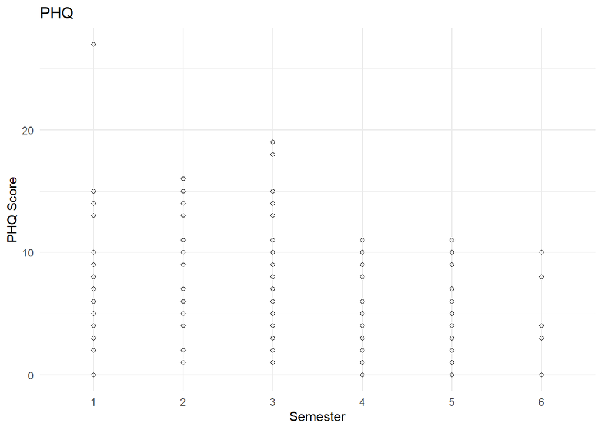

```r
ggplot(data_scores, aes(Semester, phq)) +
  geom_point(pch = 21) +
  labs(title = "PHQ", x = "Semester", y = "PHQ Score") +
  theme_minimal()
```

```r
lm1 <- lm(phq ~ Semester, data = data_scores)
summary(lm1)
```

```
Call:
lm(formula = phq ~ Semester, data = data_scores)

Residuals:
    Min      1Q  Median      3Q     Max
-7.3182 -2.7209 -0.7778  2.1635 20.2791

Coefficients:
            Estimate Std. Error t value Pr(>|t|)
(Intercept)   6.7209     0.6189  10.859  < 2e-16 ***
Semester2     0.4306     0.9393   0.458  0.64717
Semester3     1.5973     0.8703   1.835  0.06803 .
Semester4    -2.8459     0.9475  -3.004  0.00303 **
Semester5    -1.3495     0.9240  -1.461  0.14579
Semester6    -1.9432     1.4877  -1.306  0.19309
---
Signif. codes:  0 '***' 0.001 '**' 0.01 '*' 0.05 '.' 0.1 ' ' 1

Residual standard error: 4.059 on 190 degrees of freedom
Multiple R-squared:  0.1255,    Adjusted R-squared:  0.1025
F-statistic: 5.456 on 5 and 190 DF,  p-value: 0.0001026
```

```r
em <- emmeans(lm1, "Semester")
pairs(em, adjust = "tukey")
```

```
 contrast              estimate    SE  df t.ratio p.value
 Semester1 - Semester2   -0.431 0.939 190  -0.458  0.9974
 Semester1 - Semester3   -1.597 0.870 190  -1.835  0.4457
 Semester1 - Semester4    2.846 0.948 190   3.004  0.0353
 Semester1 - Semester5    1.350 0.924 190   1.461  0.6897
 Semester1 - Semester6    1.943 1.490 190   1.306  0.7814
 Semester2 - Semester3   -1.167 0.935 190  -1.248  0.8123
 Semester2 - Semester4    3.277 1.010 190   3.254  0.0167
 Semester2 - Semester5    1.780 0.985 190   1.808  0.4633
 Semester2 - Semester6    2.374 1.530 190   1.555  0.6289
 Semester3 - Semester4    4.443 0.943 190   4.712 <0.0001
 Semester3 - Semester5    2.947 0.919 190   3.206  0.0194
 Semester3 - Semester6    3.540 1.480 190   2.384  0.1670
 Semester4 - Semester5   -1.496 0.993 190  -1.507  0.6599
 Semester4 - Semester6   -0.903 1.530 190  -0.590  0.9916
 Semester5 - Semester6    0.594 1.520 190   0.391  0.9988

P value adjustment: tukey method for comparing a family of 6 estimates
```

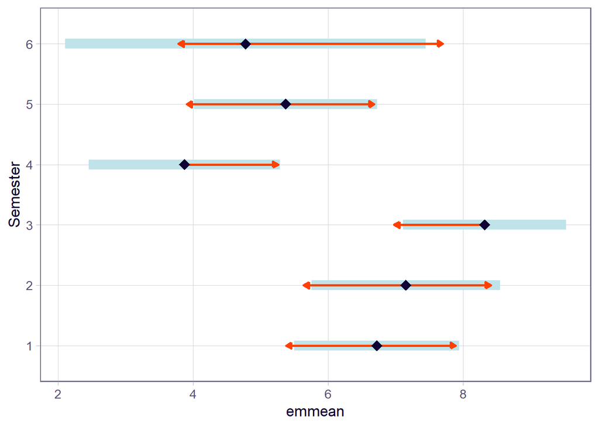

```r
plot(em, comparisons = TRUE)
```

```r
# lm2 <- lm(phq ~ 0 + Semester, data = data_scores)
# summary(lm2)
```

Interpretation:

Like with the original results, semester 2, 5, and 6 have high p-values, which means there is not suffiecient evidence to suggest that those semesters are significantly different than those in the first semester. Semester 4 has a p-value less than 0.05, which means there is sufficient evidence that PHQ scores are significantly different in Semester 4 compared to Semester 1. Semester 3 has a p-value that is on the border of a few different significance levels. This means that there is some evidence to suggest that Semester 3 is significantly different from Semester 1, but it depends on where we decide to draw the line in the sand on what is significant or not. From this, we can still follow the conclusion that was drawn with the original results, but with a weaker argument for how different Semester 3 is from Semester 1. This gives more credit to the possibility that there are outliers in our data that are inflating Semester 3’s results.

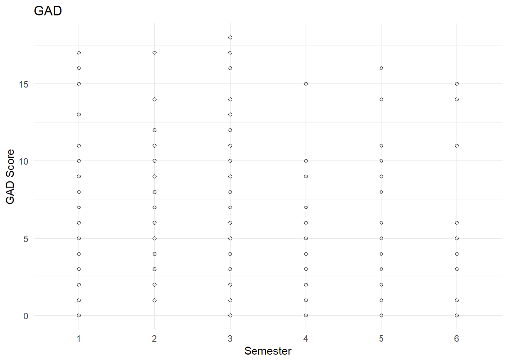

```r
ggplot(data_scores, aes(Semester, gad)) +
  geom_point(pch = 21) +
  labs(title = "GAD", x = "Semester", y = "GAD Score") +
  theme_minimal()
```

```r
lm3 <- lm(gad ~ Semester, data = data_scores)
summary(lm3)
```

```
Call:
lm(formula = gad ~ Semester, data = data_scores)

Residuals:
    Min      1Q  Median      3Q     Max
-7.9091 -3.1860 -0.9714  2.6563 11.6563

Coefficients:
            Estimate Std. Error t value Pr(>|t|)
(Intercept)   7.1860     0.6657  10.794  < 2e-16 ***
Semester2    -0.7315     1.0103  -0.724 0.469917
Semester3     0.7230     0.9361   0.772 0.440836
Semester4    -3.8423     1.0192  -3.770 0.000218 ***
Semester5    -2.2146     0.9938  -2.228 0.027025 *
Semester6    -0.6305     1.6002  -0.394 0.694013
---
Signif. codes:  0 '***' 0.001 '**' 0.01 '*' 0.05 '.' 0.1 ' ' 1

Residual standard error: 4.365 on 190 degrees of freedom
Multiple R-squared:  0.1186,    Adjusted R-squared:  0.09544
F-statistic: 5.115 on 5 and 190 DF,  p-value: 0.0002004
```

```r
em <- emmeans(lm3, "Semester")
pairs(em, adjust = "tukey")
```

```
 contrast              estimate    SE  df t.ratio p.value
 Semester1 - Semester2    0.732 1.010 190   0.724  0.9788
 Semester1 - Semester3   -0.723 0.936 190  -0.772  0.9718
 Semester1 - Semester4    3.842 1.020 190   3.770  0.0029
 Semester1 - Semester5    2.215 0.994 190   2.228  0.2297
 Semester1 - Semester6    0.630 1.600 190   0.394  0.9988
 Semester2 - Semester3   -1.455 1.010 190  -1.447  0.6982
 Semester2 - Semester4    3.111 1.080 190   2.872  0.0509
 Semester2 - Semester5    1.483 1.060 190   1.400  0.7269
 Semester2 - Semester6   -0.101 1.640 190  -0.062  1.0000
 Semester3 - Semester4    4.565 1.010 190   4.501  0.0002
 Semester3 - Semester5    2.938 0.989 190   2.971  0.0387
 Semester3 - Semester6    1.354 1.600 190   0.848  0.9581
 Semester4 - Semester5   -1.628 1.070 190  -1.524  0.6490
 Semester4 - Semester6   -3.212 1.650 190  -1.950  0.3752
 Semester5 - Semester6   -1.584 1.630 190  -0.971  0.9266

P value adjustment: tukey method for comparing a family of 6 estimates
```

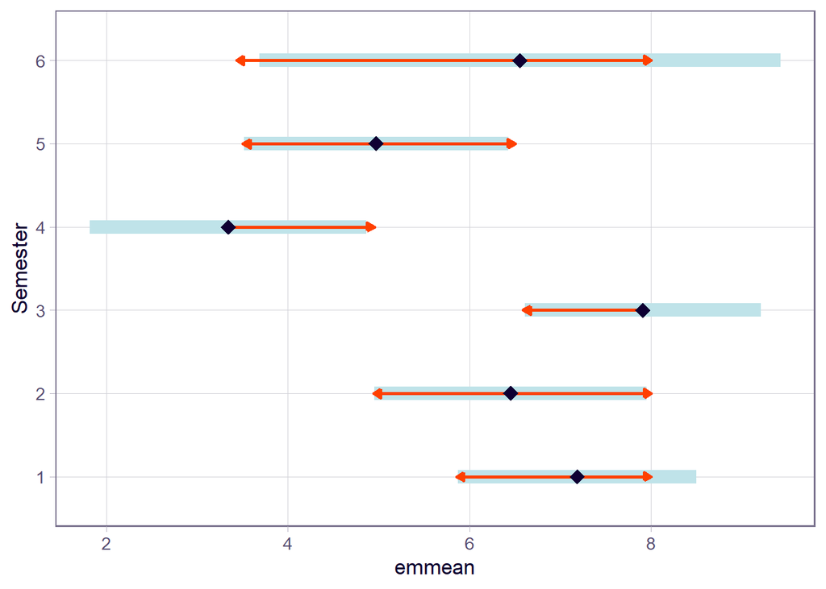

```r
plot(em, comparisons = TRUE)
```

```r
# lm4 <- lm(gad ~ 0 + Semester, data = data_scores)
# summary(lm4)
```

Interpretation:

The results from this test lead to the same conslusions as the original results. Semester 4 and 5 have low enough p-values to suggest that there is sufficient evidence to suggest that there is a significant difference between those semesters and semester 1. This suggests that anxiety is generally lower in Semesters 4 and 5 compared to Semester 1.

# Generalized Model - Depressed v Not Depressed; Anxious v Not Anxious:

## Depressed

```r
depressed <- data_scores |>
  select(Semester:phq, Q3_1_value:Q3_9_value) |>
  mutate(shaded_count = rowSums(across(Q3_1_value:Q3_8_value, ~ .x %in% 2:3)),
         shaded_count = ifelse(Q3_9_value > 0, shaded_count + 1, shaded_count),
         core_symptom_check = (Q3_1_value %in% 2:3) | (Q3_2_value %in% 2:3),
         probable_depression = ifelse(shaded_count >= 2 & core_symptom_check, 1, 0)
         )

glm1 <- glm(probable_depression ~ Semester, data = depressed, family = "binomial")
summary(glm1)
```

```
Call:
glm(formula = probable_depression ~ Semester, family = "binomial",
    data = depressed)

Coefficients:
             Estimate Std. Error z value Pr(>|z|)
(Intercept)   -1.8192     0.4401  -4.133 3.57e-05 ***
Semester2      0.3151     0.6304   0.500    0.617
Semester3      0.1542     0.6030   0.256    0.798
Semester4     -1.6148     1.1072  -1.458    0.145
Semester5     -0.9842     0.8509  -1.157    0.247
Semester6    -15.7469  1318.7268  -0.012    0.990
---
Signif. codes:  0 '***' 0.001 '**' 0.01 '*' 0.05 '.' 0.1 ' ' 1

(Dispersion parameter for binomial family taken to be 1)

    Null deviance: 137.66  on 195  degrees of freedom
Residual deviance: 128.84  on 190  degrees of freedom
AIC: 140.84

Number of Fisher Scoring iterations: 16
```

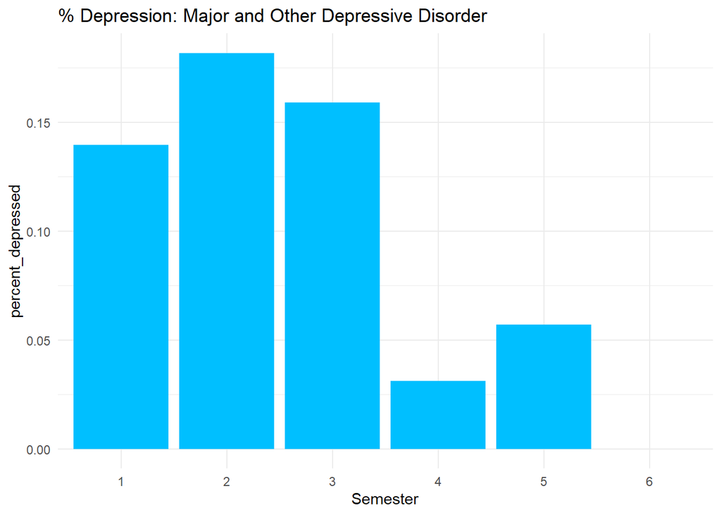

```r
depressed_pct <- depressed %>%
  group_by(Semester) %>%
  summarise(
    n_total = n(),
    n_depressed = sum(probable_depression == TRUE, na.rm = TRUE),
    percent_depressed = n_depressed / n_total
  )

ggplot(depressed_pct, aes(Semester, percent_depressed)) +
  geom_col(fill = "deepskyblue") +
  labs(title = "% Depression: Major and Other Depressive Disorder") +
  theme_minimal()
```

```r
#no significance in pairwise comparisons

em <- emmeans(glm1, "Semester")

pairs(em, adjust = "tukey")
```

```
 contrast              estimate       SE  df z.ratio p.value
 Semester1 - Semester2   -0.315    0.630 Inf  -0.500  0.9962
 Semester1 - Semester3   -0.154    0.603 Inf  -0.256  0.9999
 Semester1 - Semester4    1.615    1.110 Inf   1.458  0.6909
 Semester1 - Semester5    0.984    0.851 Inf   1.157  0.8573
 Semester1 - Semester6   15.747 1320.000 Inf   0.012  1.0000
 Semester2 - Semester3    0.161    0.611 Inf   0.263  0.9998
 Semester2 - Semester4    1.930    1.110 Inf   1.736  0.5078
 Semester2 - Semester5    1.299    0.857 Inf   1.517  0.6536
 Semester2 - Semester6   16.062 1320.000 Inf   0.012  1.0000
 Semester3 - Semester4    1.769    1.100 Inf   1.613  0.5896
 Semester3 - Semester5    1.138    0.837 Inf   1.360  0.7508
 Semester3 - Semester6   15.901 1320.000 Inf   0.012  1.0000
 Semester4 - Semester5   -0.631    1.250 Inf  -0.504  0.9960
 Semester4 - Semester6   14.132 1320.000 Inf   0.011  1.0000
 Semester5 - Semester6   14.763 1320.000 Inf   0.011  1.0000

Results are given on the log odds ratio (not the response) scale.
P value adjustment: tukey method for comparing a family of 6 estimates
```

```r
# depressed <- data_scores |>
#   select(Semester:phq, Q3_1_value:Q3_9_value) |>
#   mutate(shaded_count = rowSums(across(Q3_1_value:Q3_8_value, ~ .x %in% 2:3)),
#          shaded_count = ifelse(Q3_9_value > 0, shaded_count + 1, shaded_count),
#          core_symptom_check = (Q3_1_value %in% 2:3) | (Q3_2_value %in% 2:3),
#          maj_depression = ifelse(shaded_count >= 5 & core_symptom_check, 1, 0)
#          )
#
# glm1 <- glm(maj_depression ~ Semester, data = depressed)
# summary(glm1)
#
# depressed_pct <- depressed %>%
#   group_by(Semester) %>%
#   summarise(
#     n_total = n(),
#     n_depressed = sum(maj_depression == TRUE, na.rm = TRUE),
#     percent_depressed = n_depressed / n_total
#   )
#
# ggplot(depressed_pct, aes(Semester, percent_depressed)) +
#   geom_col(fill = "deepskyblue") +
#   labs(title = "% Depression: Major Depressive Disorder") +
#   theme_minimal()
#
#
# depressed <- data_scores |>
#   select(Semester:phq, Q3_1_value:Q3_9_value) |>
#   mutate(shaded_count = rowSums(across(Q3_1_value:Q3_8_value, ~ .x %in% 2:3)),
#          shaded_count = ifelse(Q3_9_value > 0, shaded_count + 1, shaded_count),
#          core_symptom_check = (Q3_1_value %in% 2:3) | (Q3_2_value %in% 2:3),
#          other_depression = ifelse(shaded_count >= 2 & shaded_count <=4 & core_symptom_check, 1, 0)
#          )
#
# glm1 <- glm(other_depression ~ Semester, data = depressed)
# summary(glm1)
#
# depressed_pct <- depressed %>%
#   group_by(Semester) %>%
#   summarise(
#     n_total = n(),
#     n_depressed = sum(other_depression == TRUE, na.rm = TRUE),
#     percent_depressed = n_depressed / n_total
#   )
#
# ggplot(depressed_pct, aes(Semester, percent_depressed)) +
#   geom_col(fill = "deepskyblue") +
#   labs(title = "% Depression: Other Depressive Disorder") +
#   theme_minimal()
#
# depressed <- data_scores |>
#   select(Semester:phq, Q3_1_value:Q3_9_value) |>
#   mutate(depression = ifelse(phq >= 15, 1, 0))
#
# glm1 <- glm(depression ~ Semester, data = depressed)
# summary(glm1)
#
# depressed_pct <- depressed %>%
#   group_by(Semester) %>%
#   summarise(
#     n_total = n(),
#     n_depressed = sum(depression == TRUE, na.rm = TRUE),
#     percent_depressed = n_depressed / n_total
#   )
#
# ggplot(depressed_pct, aes(Semester, percent_depressed)) +
#   geom_col(fill = "deepskyblue") +
#   labs(title = "% Depression: PHQ Score >= 15") +
#   theme_minimal()
#
# depressed <- data_scores |>
#   select(Semester:phq, Q3_1_value:Q3_9_value) |>
#   mutate(depression = ifelse(phq >= 20, 1, 0))
#
# glm1 <- glm(depression ~ Semester, data = depressed)
# summary(glm1)
#
# depressed_pct <- depressed %>%
#   group_by(Semester) %>%
#   summarise(
#     n_total = n(),
#     n_depressed = sum(depression == TRUE, na.rm = TRUE),
#     percent_depressed = n_depressed / n_total
#   )
#
# ggplot(depressed_pct, aes(Semester, percent_depressed)) +
#   geom_col(fill = "deepskyblue") +
#   labs(title = "% Depression: PHQ Score >= 20") +
#   theme_minimal()
```

This model and graph defines someone with depression when there are at least 2 checks in the shaded section, with at least one of them being Question 1 or 2. Like with the original results, there is not sufficient evidence that Semester has a significant relationship with depression. This is further confirmed with the second test, which has no significance anywhere.

## Anxious

```r
anxiety <- data_scores |>
  select(Semester, Q5_1:gad, Q5_1_value:Q5_7_value) |>
  mutate(severe_anxiety = ifelse(gad >= 15, 1, 0),
         anxiety_type = case_when(
           gad < 5 ~ "Minimal",
           gad < 10 ~ "Mild",
           gad < 15 ~ "Moderate",
           gad >=15 ~ "Severe"
         ))

glm2 <- glm(severe_anxiety ~ Semester, data = anxiety, , family = "binomial")
summary(glm2)
```

```
Call:
glm(formula = severe_anxiety ~ Semester, family = "binomial",
    data = anxiety)

Coefficients:
            Estimate Std. Error z value Pr(>|z|)
(Intercept) -1.81916    0.44011  -4.133 3.57e-05 ***
Semester2   -1.64658    1.10677  -1.488    0.137
Semester3   -0.02667    0.62183  -0.043    0.966
Semester4   -1.61483    1.10723  -1.458    0.145
Semester5   -1.70720    1.10594  -1.544    0.123
Semester6   -0.26028    1.14834  -0.227    0.821
---
Signif. codes:  0 '***' 0.001 '**' 0.01 '*' 0.05 '.' 0.1 ' ' 1

(Dispersion parameter for binomial family taken to be 1)

    Null deviance: 110.83  on 195  degrees of freedom
Residual deviance: 103.03  on 190  degrees of freedom
AIC: 115.03

Number of Fisher Scoring iterations: 6
```

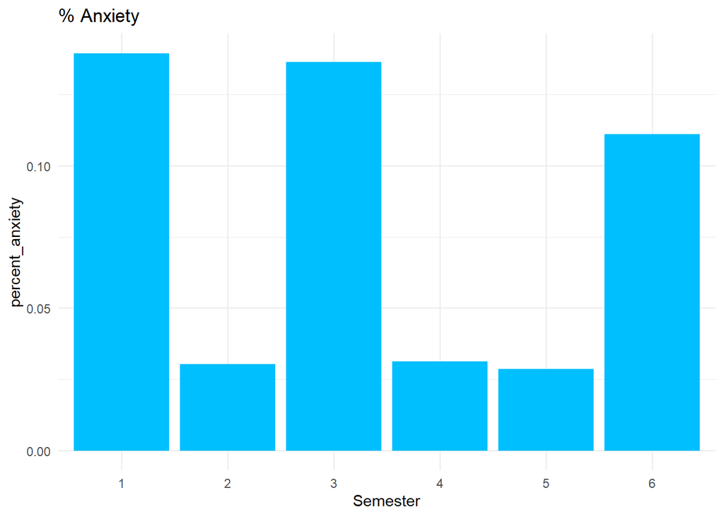

```r
anxiety_pct <- anxiety %>%
  group_by(Semester) %>%
  summarise(
    n_total = n(),
    n_anxiety = sum(severe_anxiety == TRUE, na.rm = TRUE),
    percent_anxiety = n_anxiety / n_total
  )

ggplot(anxiety_pct, aes(Semester, percent_anxiety)) +
  geom_col(fill = "deepskyblue") +
  labs(title = "% Anxiety") +
  theme_minimal()
```

```r
em <- emmeans(glm2, "Semester")

pairs(em, adjust = "tukey")
```

```
 contrast              estimate    SE  df z.ratio p.value
 Semester1 - Semester2   1.6466 1.110 Inf   1.488  0.6722
 Semester1 - Semester3   0.0267 0.622 Inf   0.043  1.0000
 Semester1 - Semester4   1.6148 1.110 Inf   1.458  0.6909
 Semester1 - Semester5   1.7072 1.110 Inf   1.544  0.6358
 Semester1 - Semester6   0.2603 1.150 Inf   0.227  0.9999
 Semester2 - Semester3  -1.6199 1.110 Inf  -1.464  0.6873
 Semester2 - Semester4  -0.0317 1.440 Inf  -0.022  1.0000
 Semester2 - Semester5   0.0606 1.440 Inf   0.042  1.0000
 Semester2 - Semester6  -1.3863 1.470 Inf  -0.944  0.9350
 Semester3 - Semester4   1.5882 1.110 Inf   1.435  0.7057
 Semester3 - Semester5   1.6805 1.110 Inf   1.520  0.6513
 Semester3 - Semester6   0.2336 1.150 Inf   0.203  1.0000
 Semester4 - Semester5   0.0924 1.440 Inf   0.064  1.0000
 Semester4 - Semester6  -1.3545 1.470 Inf  -0.922  0.9409
 Semester5 - Semester6  -1.4469 1.470 Inf  -0.986  0.9226

Results are given on the log odds ratio (not the response) scale.
P value adjustment: tukey method for comparing a family of 6 estimates
```

# Confidence Intervals:

```r
anxiety_stuff <- anxiety |>
  group_by(anxiety_type) |>
  summarise(count = n(), pro = count/nrow(anxiety), per = pro * 100)
```

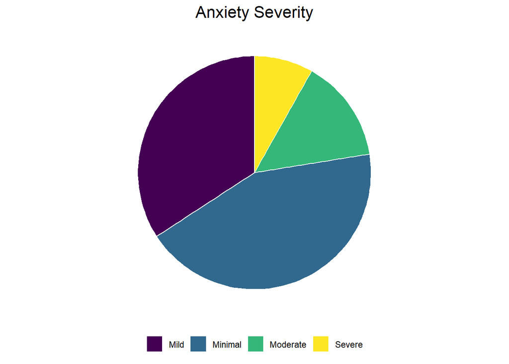

```r
ggplot(anxiety_stuff, aes(x = "", y = pro, fill = anxiety_type)) +
  geom_col(width = 1, color = "white") +
  coord_polar(theta = "y") +
  labs(
    title = "Anxiety Severity",
    fill = NULL,
    x = NULL,
    y = NULL
  ) +
  theme_minimal() +
  theme(
    plot.title = element_text(hjust = 0.5, size = 16),
    legend.position = "bottom",
    axis.text = element_blank(),
    axis.ticks = element_blank(),
    panel.grid = element_blank()
  ) +
  scale_fill_viridis_d()
```

```r
pander(anxiety_stuff)
```

| anxiety_type | count | pro | per |
| --- | --- | --- | --- |
| Mild | 67 | 0.3418 | 34.18 |
| Minimal | 85 | 0.4337 | 43.37 |
| Moderate | 28 | 0.1429 | 14.29 |
| Severe | 16 | 0.08163 | 8.163 |

```r
a_ci <- binom.test(16, 196)
#a_ci$conf.int[1]
#print("95% Confidence Interval for Severe Anxiety")
```

##### 95% Confidence Interval for Severe Anxiety

```r
paste0("(", round(a_ci$conf.int[1] * 100,2), ", ", round(a_ci$conf.int[2] * 100,2),")%")
```

```
[1] "(4.74, 12.92)%"
```

```r
depression_stuff <- depressed |>
  mutate(depression_type = case_when(
           phq < 5 ~ "Minimal",
           phq < 10 ~ "Mild",
           phq < 15 ~ "Moderate",
           phq >=15 ~ "Severe"
         )) |>
  group_by(depression_type) |>
  summarise(count = n(), proportion = count/nrow(depressed), percent = proportion * 100)
```

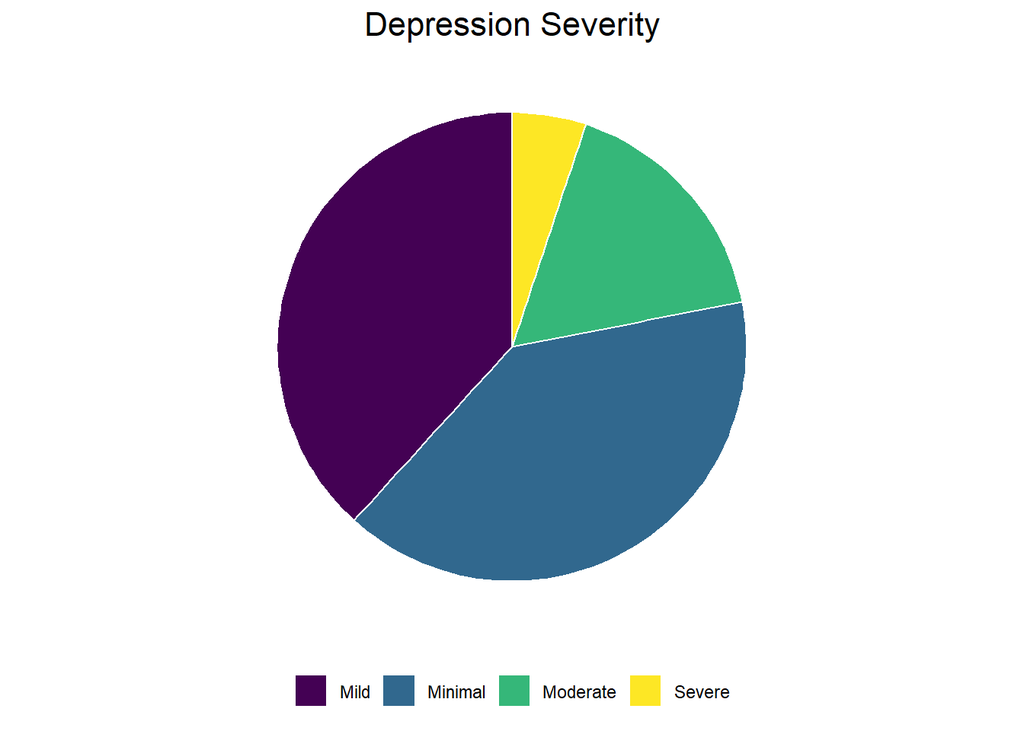

```r
ggplot(depression_stuff, aes(x = "", y = proportion, fill = depression_type)) +
  geom_col(width = 1, color = "white") +
  coord_polar(theta = "y") +
  labs(
    title = "Depression Severity",
    fill = NULL,
    x = NULL,
    y = NULL
  ) +
  theme_minimal() +
  theme(
    plot.title = element_text(hjust = 0.5, size = 16),
    legend.position = "bottom",
    axis.text = element_blank(),
    axis.ticks = element_blank(),
    panel.grid = element_blank()
  ) +
  scale_fill_viridis_d()
```

```r
pander(depression_stuff)
```

| depression_type | count | proportion | percent |
| --- | --- | --- | --- |
| Mild | 75 | 0.3827 | 38.27 |
| Minimal | 78 | 0.398 | 39.8 |
| Moderate | 33 | 0.1684 | 16.84 |
| Severe | 10 | 0.05102 | 5.102 |

```r
d_ci <- binom.test(1, 196)
#a_ci$conf.int[1]
#print("95% Confidence Interval for Severe Depression")
```

```r
paste0("(", round(d_ci$conf.int[1] * 100,2), ", ", round(d_ci$conf.int[2] * 100,2),")%")
```

```
[1] "(0.01, 2.81)%"
```

# Resource Utilization

## We want to measure what percentage of students that are indicative of anxiety are using resources in general and using BYU specific resources (CAPS or wellness center).

### Anxiety Severity Types

The table and graph below represent the same information. They give an overview for who uses which resources more based on Anxiety levels.

```r
anx_resources <- full_data |>
  group_by(anxiety_type) |>
  summarise(
    general_resources = mean(used_resource, na.rm = TRUE) * 100,
    byu_resources = mean(byu_resource, na.rm = TRUE) * 100,
    non_byu_resources = mean(non_byu_resources, na.rm = TRUE) * 100,
    n = n()
  )

table <- anx_resources |>
  rename(`Anxiety Severity` = anxiety_type, `All Resources` = general_resources, `BYU Resources` = byu_resources, `Non-BYU Resources` = non_byu_resources)

pander(table)
```

| Anxiety Severity | All Resources | BYU Resources | Non-BYU Resources | n |
| --- | --- | --- | --- | --- |
| Mild | 46.27 | 11.94 | 37.31 | 67 |
| Minimal | 43.53 | 2.353 | 41.18 | 85 |
| Moderate | 57.14 | 10.71 | 46.43 | 28 |
| Severe | 75 | 6.25 | 68.75 | 16 |

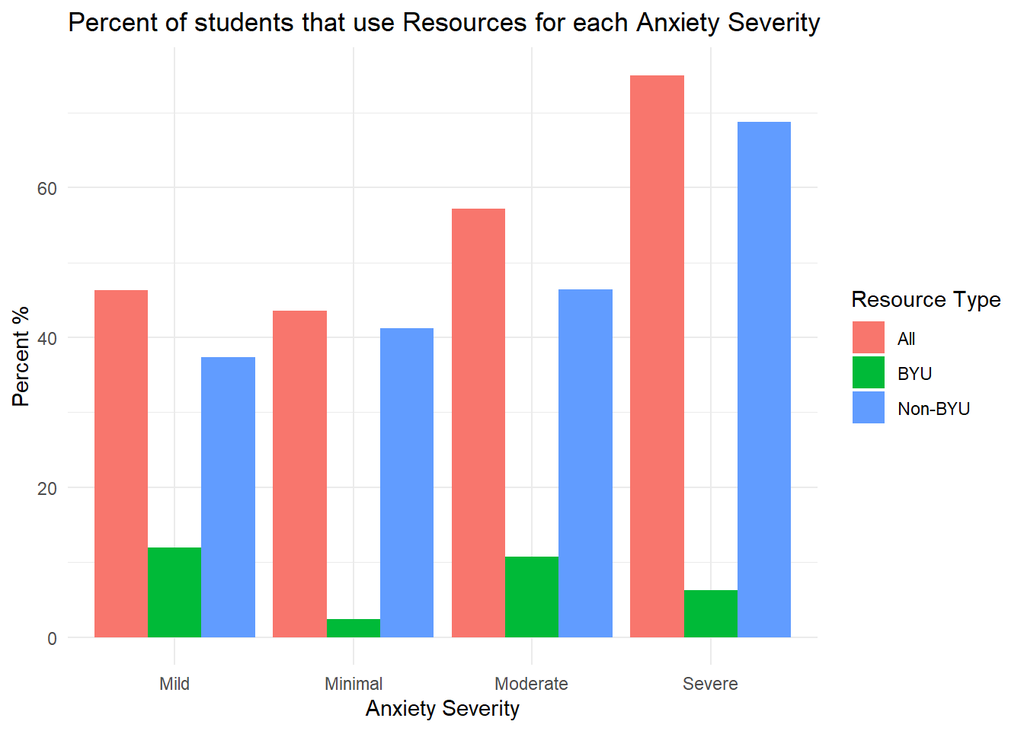

```r
anx_graph <- anx_resources |>
  select(-n) |>
  pivot_longer(cols = c("general_resources", "byu_resources", "non_byu_resources"),
               names_to = "resource",
               values_to = "percent") |>
  mutate(resource = ifelse(resource == "byu_resources", "BYU", resource)) |>
  mutate(resource = ifelse(resource == "non_byu_resources", "Non-BYU", resource)) |>
  mutate(resource = ifelse(resource == "general_resources", "All", resource))

ggplot(anx_graph, aes(anxiety_type, percent, fill = resource)) +
  geom_col(position = "dodge") +
  labs(title = "Percent of students that use Resources for each Anxiety Severity",
       x = "Anxiety Severity",
       y = "Percent %",
       fill = "Resource Type") +
  theme_minimal()
```

It is interesting to note that though resource usage seems to increase as Anxiety Severity increases, there is a dip in who uses the resources in the minimal group. To check if this was significant I ran the below test.

#### Chi-squared Test Results

###### All Resources

```r
x <- table(full_data$anxiety_type, full_data$used_resource)

test <- chisq.test(x, simulate.p.value = TRUE)
# test$expected
paste("P-value:", round(test$p.value, 3))
```

```
[1] "P-value: 0.096"
```

```r
pander(test$residuals, caption = "Pearson Residuals")
```

Pearson Residuals

|  | 0 | 1 |
| --- | --- | --- |
| **Mild** | 0.3107 | -0.3171 |
| **Minimal** | 0.7035 | -0.718 |
| **Moderate** | -0.6047 | 0.6172 |
| **Severe** | -1.457 | 1.487 |

A chi-squared test checks to see if two variables are independent of eachother by comparing what values we would expect to see if there was no relationship with what we actually observe. In the above results we check to see if anxiety severity has a relationship with all resources. The p-value is too high, indicating that there is insufficient evidence that anxiety severity and all resources used are not independent of eachother. Had the results been significant, we would look at the Pearson Residuals to indicate how strong the relationship is between certain categories. The further from 0 a residual is, the stronger the relationship.

###### BYU Resources

```r
x <- table(full_data$anxiety_type, full_data$byu_resource)

test <- chisq.test(x, simulate.p.value = TRUE)
# test$expected
paste("P-value:", round(test$p.value, 3))
```

```
[1] "P-value: 0.1"
```

```r
pander(test$residuals, caption = "Pearson Residuals")
```

Pearson Residuals

|  | 0 | 1 |
| --- | --- | --- |
| **Mild** | -0.4075 | 1.469 |
| **Minimal** | 0.4583 | -1.652 |
| **Moderate** | -0.1961 | 0.7071 |
| **Severe** | 0.03706 | -0.1336 |

This trend continues when we just look at BYU resources (test results above) and non-BYU resources (test results below). The p-values are to high to conclude that there is a signifcant relationship between anxiety type and use of resources.

###### Non-BYU Resources

```r
x <- table(full_data$anxiety_type, full_data$non_byu_resources)

test <- chisq.test(x, simulate.p.value = TRUE)
# test$expected
paste("P-value:", round(test$p.value, 3))
```

```
[1] "P-value: 0.138"
```

```r
pander(test$residuals, caption = "Pearson Residuals")
```

Pearson Residuals

|  | 0 | 1 |
| --- | --- | --- |
| **Mild** | 0.6003 | -0.6931 |
| **Minimal** | 0.205 | -0.2367 |
| **Moderate** | -0.25 | 0.2887 |
| **Severe** | -1.37 | 1.582 |

### Severe Anxiety

This graph and table is the same as the first ones, but now categorize everyone based on whether or not they have severe anxiety.

```r
anx_resources <- full_data |>
  group_by(severe_anxiety) |>
  summarise(
    general_resources = mean(used_resource, na.rm = TRUE) * 100,
    byu_resources = mean(byu_resource, na.rm = TRUE) * 100,
    non_byu_resources = mean(non_byu_resources, na.rm = TRUE) * 100,
    n = n()
  )

table <- anx_resources |>
  mutate(severe_anxiety = ifelse(severe_anxiety == 1, "True", "False")) |>
  rename(`Severe Anxiety` = severe_anxiety, `All Resources` = general_resources, `BYU Resources` = byu_resources, `Non-BYU Resources` = non_byu_resources)

pander(table)
```

| Severe Anxiety | All Resources | BYU Resources | Non-BYU Resources | n |
| --- | --- | --- | --- | --- |
| False | 46.67 | 7.222 | 40.56 | 180 |
| True | 75 | 6.25 | 68.75 | 16 |

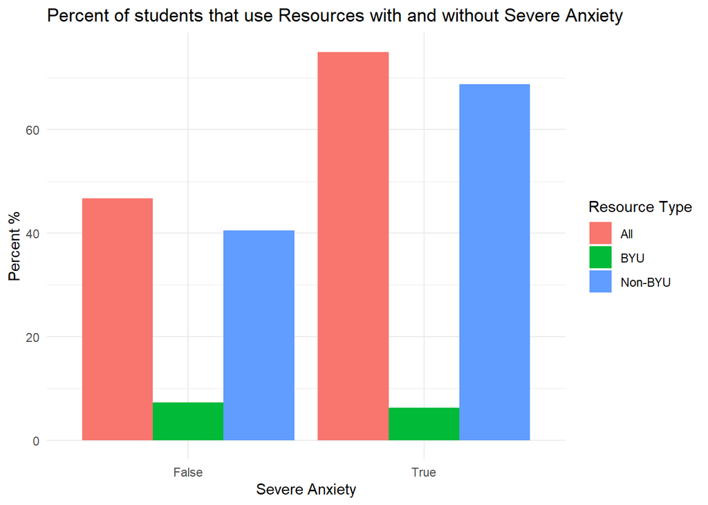

```r
anx_graph <- anx_resources |>
  select(-n) |>
  pivot_longer(cols = c("general_resources", "byu_resources", "non_byu_resources"),
               names_to = "resource",
               values_to = "percent") |>
  mutate(severe_anxiety = ifelse(severe_anxiety == 1, "True", "False")) |>
  mutate(resource = ifelse(resource == "byu_resources", "BYU", resource)) |>
  mutate(resource = ifelse(resource == "non_byu_resources", "Non-BYU", resource)) |>
  mutate(resource = ifelse(resource == "general_resources", "All", resource))


ggplot(anx_graph, aes(severe_anxiety, percent, fill = resource)) +
  geom_col(position = "dodge") +
  labs(title = "Percent of students that use Resources with and without Severe Anxiety",
       x = "Severe Anxiety",
       y = "Percent %",
       fill = "Resource Type") +
  theme_minimal()
```

#### Fisher’s and Chi-squared test results

###### All Resources

```r
x <- table(full_data$severe_anxiety, full_data$used_resource)

test <- chisq.test(x)
#summary(test)

# test <- fisher.test(full_data$severe_anxiety, full_data$used_resource, simulate.p.value = TRUE, B = 100000)

paste("P-value:", round(test$p.value, 3))
```

```
[1] "P-value: 0.056"
```

```r
test$residuals
```

```
             0          1
  0  0.4344361 -0.4433945
  1 -1.4571429  1.4871902
```

Above if the p-value for testing if there is a relationship between whether having severe anxiety or not and using either BYU or non-BYU resources. This p-value is on the border of whether we would consider there to be sufficient evidence that people are more likely to use general resources with severe anxiety than without.

###### BYU Resources

```r
# x <- table(full_data$severe_anxiety, full_data$byu_resource)
#
# test <- chisq.test(x)
# test$expected

test <- fisher.test(full_data$severe_anxiety, full_data$byu_resource, simulate.p.value = TRUE, B = 100000)

paste("P-value:", round(test$p.value, 3))
```

```
[1] "P-value: 1"
```

This test checks for the same thing, but looks at BYU specific resources instead. This p-value is a perfect 1 and therefore leaves us with the conclusion that there is not sufficient evidence that there is a significant difference between having severe anxiety and using BYU resources.

###### Non-BYU Resources

```r
x <- table(full_data$severe_anxiety, full_data$non_byu_resources)

test <- chisq.test(x)
#test$expected

# test <- fisher.test(full_data$severe_anxiety, full_data$non_byu_resources, simulate.p.value = TRUE, B = 100000)

paste("P-value:", round(test$p.value, 3))
```

```
[1] "P-value: 0.055"
```

```r
test$residuals
```

```
             0          1
  0  0.4084912 -0.4716850
  1 -1.3701212  1.5820797
```

This p-value is also on the border of significance. This most likely means that there could be a relationship between using resources and having severe anxiety, but we would need more data to show a strong relationship between the two.

## We want to repeat those steps for students indicative of depression. We also want to look at what percentage of students that are NOT considered depressed are using resources for depression same as above but BYU specific resources

### Depression Severity Type

These tables and graphs are the same as for anxiety, but are now for depression.

```r
dep_resources <- full_data |>
  group_by(depression_type) |>
  summarise(
    general_resources = mean(used_resource, na.rm = TRUE) * 100,
    byu_resources = mean(byu_resource, na.rm = TRUE) * 100,
    non_byu_resources = mean(non_byu_resources, na.rm = TRUE) * 100,
    n = n()
  )

table <- dep_resources |>
  rename(`Depression Severity` = depression_type, `All Resources` = general_resources, `BYU Resources` = byu_resources, `Non-BYU Resources` = non_byu_resources)

pander(table)
```

| Depression Severity | All Resources | BYU Resources | Non-BYU Resources | n |
| --- | --- | --- | --- | --- |
| Mild | 52 | 9.333 | 45.33 | 75 |
| Minimal | 37.18 | 2.564 | 34.62 | 78 |
| Moderate | 63.64 | 12.12 | 51.52 | 33 |
| Severe | 70 | 10 | 60 | 10 |

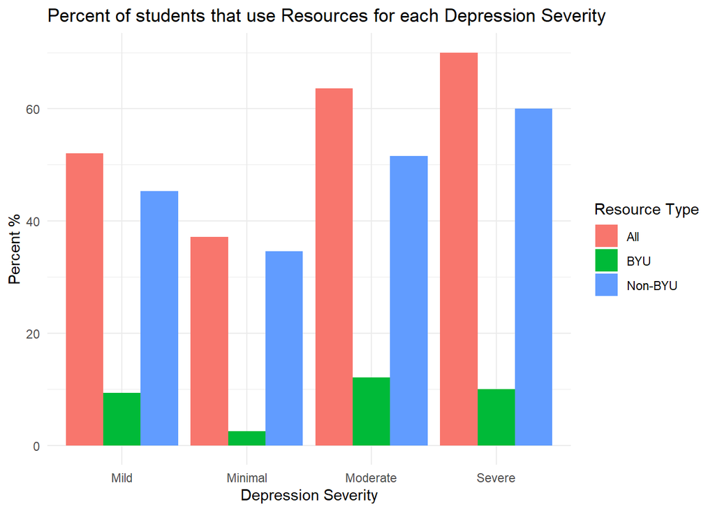

```r
dep_graph <- dep_resources |>
  select(-n) |>
  pivot_longer(cols = c("general_resources", "byu_resources", "non_byu_resources"),
               names_to = "resource",
               values_to = "percent") |>
  mutate(resource = ifelse(resource == "byu_resources", "BYU", resource)) |>
  mutate(resource = ifelse(resource == "non_byu_resources", "Non-BYU", resource)) |>
  mutate(resource = ifelse(resource == "general_resources", "All", resource))

ggplot(dep_graph, aes(depression_type, percent, fill = resource)) +
  geom_col(position = "dodge") +
  labs(title = "Percent of students that use Resources for each Depression Severity",
       x = "Depression Severity",
       y = "Percent %",
       fill = "Resource Type") +
  theme_minimal()
```

These new graphs and test have moderately severe and severe depression grouped together as depressed.

#### Chi-squared Test Results

###### All Resources

```r
x <- table(full_data$depression_type, full_data$used_resource)

test <- chisq.test(x, simulate.p.value = TRUE)
# test$expected
paste("P-value:", round(test$p.value, 3))
```

```
[1] "P-value: 0.027"
```

```r
pander(test$residuals, caption = "Pearson Residuals")
```

Pearson Residuals

|  | 0 | 1 |
| --- | --- | --- |
| **Mild** | -0.3662 | 0.3738 |
| **Minimal** | 1.459 | -1.489 |
| **Moderate** | -1.179 | 1.203 |
| **Severe** | -0.9306 | 0.9498 |

This test compares depression severity and the use of all resources. We do have a significant p-value for this test, and now because we combined the two categories, we meet the assumptions of this test. The main result of this test is that those with Minimal Depression tend to use resources far less than expected.

###### BYU Resources

```r
x <- table(full_data$depression_type, full_data$byu_resource)

test <- chisq.test(x, simulate.p.value = TRUE)
# test$expected
paste("P-value:", round(test$p.value, 3))
```

```
[1] "P-value: 0.215"
```

```r
pander(test$residuals, caption = "Pearson Residuals")
```

Pearson Residuals

|  | 0 | 1 |
| --- | --- | --- |
| **Mild** | -0.1969 | 0.7098 |
| **Minimal** | 0.4196 | -1.513 |
| **Moderate** | -0.2968 | 1.07 |
| **Severe** | -0.09376 | 0.3381 |

This test is for BYU specific resources. It does not have a significant p-value, but also does not quite meet all the test assumptions.

###### Non-BYU Resources

```r
x <- table(full_data$depression_type, full_data$non_byu_resources)

test <- chisq.test(x, simulate.p.value = TRUE)
# test$expected
paste("P-value:", round(test$p.value, 3))
```

```
[1] "P-value: 0.198"
```

```r
pander(test$residuals, caption = "Pearson Residuals")
```

Pearson Residuals

|  | 0 | 1 |
| --- | --- | --- |
| **Mild** | -0.2837 | 0.3276 |
| **Minimal** | 0.9629 | -1.112 |
| **Moderate** | -0.658 | 0.7597 |
| **Severe** | -0.7171 | 0.8281 |

This test for non-BYU specific resources does meet the test assumptions, but does not have a significant p-value.

### Depressed vs Not Depressed

This table and graph defines someone as having depression when there are at least 2 checks in the shaded section, with at least one of them being Question 1 or 2.

```r
dep_resources <- full_data |>
  group_by(probable_depression) |>
  summarise(
    general_resources = mean(used_resource, na.rm = TRUE) * 100,
    byu_resources = mean(byu_resource, na.rm = TRUE) * 100,
    non_byu_resources = mean(non_byu_resources, na.rm = TRUE) * 100,
    n = n())

table <- dep_resources |>
  mutate(probable_depression = ifelse(probable_depression == 1, "True", "False")) |>
  rename(Depression = probable_depression, `General Resources` = general_resources, `BYU Resources` = byu_resources)

pander(table)
```

| Depression | General Resources | BYU Resources | non_byu_resources | n |
| --- | --- | --- | --- | --- |
| False | 47.13 | 7.471 | 40.8 | 174 |
| True | 63.64 | 4.545 | 59.09 | 22 |

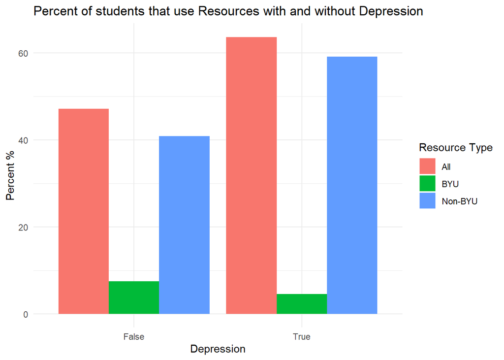

```r
dep_graph <- dep_resources |>
  select(-n) |>
  pivot_longer(cols = c("general_resources", "byu_resources", "non_byu_resources"),
               names_to = "resource",
               values_to = "percent") |>
  mutate(probable_depression = ifelse(probable_depression == 1, "True", "False")) |>
  mutate(resource = ifelse(resource == "byu_resources", "BYU", resource)) |>
  mutate(resource = ifelse(resource == "non_byu_resources", "Non-BYU", resource)) |>
  mutate(resource = ifelse(resource == "general_resources", "All", resource))

ggplot(dep_graph, aes(probable_depression, percent, fill = resource)) +
  geom_col(position = "dodge") +
  labs(title = "Percent of students that use Resources with and without Depression",
       x = "Depression",
       y = "Percent %",
       fill = "Resource Type") +
  theme_minimal()
```

#### Chi-squared test results

###### All Resources

```r
# test <- fisher.test(full_data$probable_depression, full_data$used_resource, simulate.p.value = TRUE, B = 100000)

x <- table(full_data$probable_depression, full_data$used_resource)

test <- chisq.test(x)
# test$expected
test$residuals
```

```
             0          1
  0  0.3422271 -0.3492841
  1 -0.9624489  0.9822953
```

```r
paste("P-value:", round(test$p.value, 3))
```

```
[1] "P-value: 0.217"
```

The p-values for comparing when someone is depressed and using any resource, BYU resource, or non-BYU resource are high, meaning that there is not sufficient evidence that having or not having depression has a significant relationship with using any resources.

###### BYU Resources

```r
# test <- fisher.test(full_data$probable_depression, full_data$byu_resource, simulate.p.value = TRUE, B = 100000)

x <- table(full_data$probable_depression, full_data$byu_resource)

test <- chisq.test(x)
# test$expected
test$residuals
```

```
              0           1
  0 -0.04495517  0.16208818
  1  0.12642791 -0.45584231
```

```r
paste("P-value:", round(test$p.value, 3))
```

```
[1] "P-value: 0.95"
```

###### Non-BYU Resources

```r
# test <- fisher.test(full_data$probable_depression, full_data$byu_resource, simulate.p.value = TRUE, B = 100000)

x <- table(full_data$probable_depression, full_data$non_byu_resources)

test <- chisq.test(x)
 test$expected
```

```
           0         1
  0 99.42857 74.571429
  1 12.57143  9.428571
```

```r
test$residuals
```

```
             0          1
  0  0.3581677 -0.4135764
  1 -1.0072787  1.1631053
```

```r
paste("P-value:", round(test$p.value, 3))
```

```
[1] "P-value: 0.16"
```

# Is there an interaction between Anxiety and Depression and what resources are used?

We will talk more about these results in our meeting, but the main story is that there isn’t any significant interaction between Anxiety and Depression in relation to using resources. This is most likely because we just don’t have enough data to find significant results. Many of our grouping had no one in them, meaning there was no data to test, leading to insignificant results.

```r
glm3 <- glm(used_resource ~ severe_anxiety * probable_depression, data = full_data, family = "binomial")
summary(glm3)
```

```
Call:
glm(formula = used_resource ~ severe_anxiety * probable_depression,
    family = "binomial", data = full_data)

Coefficients:
                                   Estimate Std. Error z value Pr(>|z|)
(Intercept)                        -0.15600    0.15524  -1.005    0.315
severe_anxiety                      1.07229    0.85094   1.260    0.208
probable_depression                 0.31015    0.57760   0.537    0.591
severe_anxiety:probable_depression  0.02632    1.29479   0.020    0.984

(Dispersion parameter for binomial family taken to be 1)

    Null deviance: 271.63  on 195  degrees of freedom
Residual deviance: 266.35  on 192  degrees of freedom
AIC: 274.35

Number of Fisher Scoring iterations: 4
```

```r
drop1(glm3, test = "Chisq")
```

```
Single term deletions

Model:
used_resource ~ severe_anxiety * probable_depression
                                   Df Deviance    AIC        LRT Pr(>Chi)
<none>                                  266.35 274.35
severe_anxiety:probable_depression  1   266.35 272.35 0.00041314   0.9838
```

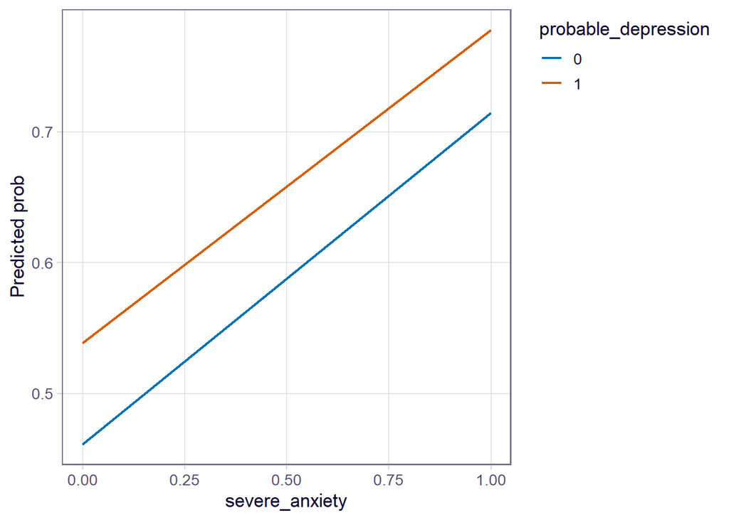

```r
check <- emmeans(glm3, ~ severe_anxiety * probable_depression, type = "response")
emmip(check,  probable_depression ~ severe_anxiety)
```

```r
glm4 <- glm(byu_resource ~ severe_anxiety * probable_depression, data = full_data, family = "binomial")
summary(glm4)
```

```
Call:
glm(formula = byu_resource ~ severe_anxiety * probable_depression,
    family = "binomial", data = full_data)

Coefficients:
                                    Estimate Std. Error z value Pr(>|z|)
(Intercept)                          -2.4720     0.2888  -8.559   <2e-16 ***
severe_anxiety                      -16.0941  2465.3257  -0.007    0.995
probable_depression                 -16.0941  1809.0545  -0.009    0.993
severe_anxiety:probable_depression   32.5807  3057.8603   0.011    0.991
---
Signif. codes:  0 '***' 0.001 '**' 0.01 '*' 0.05 '.' 0.1 ' ' 1

(Dispersion parameter for binomial family taken to be 1)

    Null deviance: 100.869  on 195  degrees of freedom
Residual deviance:  97.619  on 192  degrees of freedom
AIC: 105.62

Number of Fisher Scoring iterations: 17
```

```r
drop1(glm4, test = "Chisq")
```

```
Single term deletions

Model:
byu_resource ~ severe_anxiety * probable_depression
                                   Df Deviance    AIC    LRT Pr(>Chi)
<none>                                  97.619 105.62
severe_anxiety:probable_depression  1  100.580 106.58 2.9609   0.0853 .
---
Signif. codes:  0 '***' 0.001 '**' 0.01 '*' 0.05 '.' 0.1 ' ' 1
```

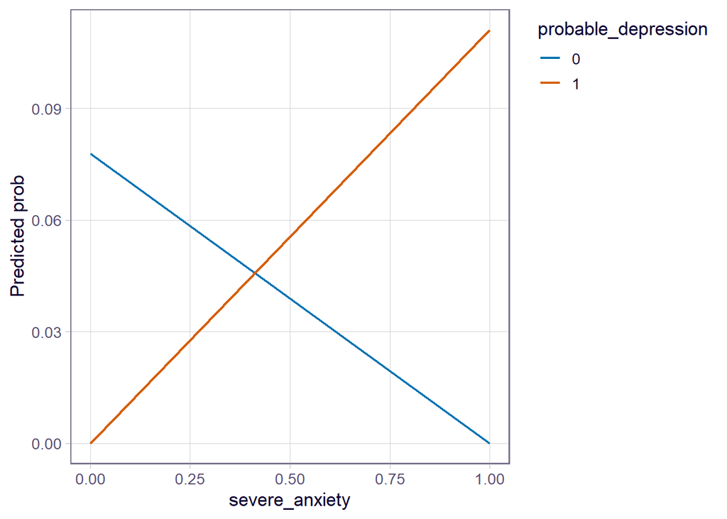

```r
check <- emmeans(glm4, ~ severe_anxiety * probable_depression, type = "response")
emmip(check,  probable_depression ~ severe_anxiety)
```

```r
glm5 <- glm(non_byu_resources ~ severe_anxiety * probable_depression, data = full_data, family = "binomial")
summary(glm5)
```

```
Call:
glm(formula = non_byu_resources ~ severe_anxiety * probable_depression,
    family = "binomial", data = full_data)

Coefficients:
                                   Estimate Std. Error z value Pr(>|z|)
(Intercept)                         -0.4255     0.1583  -2.688  0.00719 **
severe_anxiety                       1.3418     0.8515   1.576  0.11508
probable_depression                  0.5796     0.5784   1.002  0.31632
severe_anxiety:probable_depression  -0.8028     1.2388  -0.648  0.51697
---
Signif. codes:  0 '***' 0.001 '**' 0.01 '*' 0.05 '.' 0.1 ' ' 1

(Dispersion parameter for binomial family taken to be 1)

    Null deviance: 267.7  on 195  degrees of freedom
Residual deviance: 261.9  on 192  degrees of freedom
AIC: 269.9

Number of Fisher Scoring iterations: 4
```

```r
drop1(glm5, test = "Chisq")
```

```
Single term deletions

Model:
non_byu_resources ~ severe_anxiety * probable_depression
                                   Df Deviance    AIC     LRT Pr(>Chi)
<none>                                  261.90 269.90
severe_anxiety:probable_depression  1   262.32 268.32 0.42429   0.5148
```

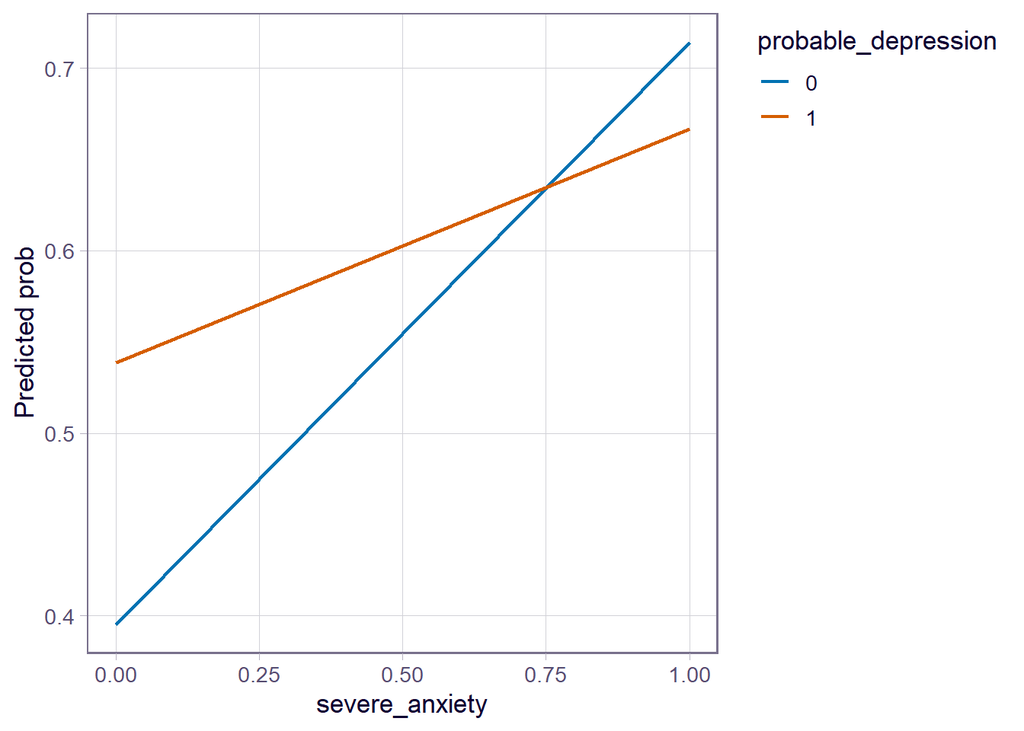

```r
check <- emmeans(glm5, ~ severe_anxiety * probable_depression, type = "response")
emmip(check,  probable_depression ~ severe_anxiety)
```

```r
# table(full_data$severe_anxiety, full_data$probable_depression, full_data$byu_resource)
#
# full_data$combo <- interaction(full_data$severe_anxiety, full_data$probable_depression)
# table(full_data$combo, full_data$byu_resource)
#
# library(logistf)
# logistf(byu_resource ~ severe_anxiety * probable_depression, data = full_data)
#
# full_data %>%
#   mutate(combo = case_when(
#     severe_anxiety == 1 & probable_depression == 1 ~ "Both",
#     severe_anxiety == 1 & probable_depression == 0 ~ "Anxiety Only",
#     severe_anxiety == 0 & probable_depression == 1 ~ "Depression Only",
#     TRUE ~ "Neither"
#   )) %>%
#   group_by(combo) %>%
#   summarise(
#     n = n(),
#     used_resource = sum(byu_resource),
#     percent = used_resource / n
#   ) %>%
#   ggplot(aes(x = combo, y = percent, fill = combo)) +
#   geom_col() +
#   labs(y = "Proportion Using BYU Resource", x = "Condition Group") +
#   theme_minimal()
```

```r
glm6 <- glm(used_resource ~ anxiety_type * depression_type, data = full_data, family = "binomial")
summary(glm6)
```

```
Call:
glm(formula = used_resource ~ anxiety_type * depression_type,
    family = "binomial", data = full_data)

Coefficients: (1 not defined because of singularities)
                                              Estimate Std. Error z value
(Intercept)                                   -0.05407    0.32892  -0.164
anxiety_typeMinimal                            0.13411    0.51812   0.259
anxiety_typeModerate                           0.61368    0.70784   0.867
anxiety_typeSevere                             0.05407    1.45196   0.037
depression_typeMinimal                        -0.95753    0.67015  -1.429
depression_typeModerate                        0.39054    0.67160   0.582
depression_typeSevere                          0.74721    1.26814   0.589
anxiety_typeMinimal:depression_typeMinimal     0.41319    0.82667   0.500
anxiety_typeModerate:depression_typeMinimal    0.39792    1.35719   0.293
anxiety_typeSevere:depression_typeMinimal      0.95753    2.10929   0.454
anxiety_typeMinimal:depression_typeModerate    0.22257    1.45303   0.153
anxiety_typeModerate:depression_typeModerate  -0.61368    1.08938  -0.563
anxiety_typeSevere:depression_typeModerate     1.21890    1.91077   0.638
anxiety_typeMinimal:depression_typeSevere           NA         NA      NA
anxiety_typeModerate:depression_typeSevere   -15.87290  882.74451  -0.018
anxiety_typeSevere:depression_typeSevere       0.86222    2.19276   0.393
                                             Pr(>|z|)
(Intercept)                                     0.869
anxiety_typeMinimal                             0.796
anxiety_typeModerate                            0.386
anxiety_typeSevere                              0.970
depression_typeMinimal                          0.153
depression_typeModerate                         0.561
depression_typeSevere                           0.556
anxiety_typeMinimal:depression_typeMinimal      0.617
anxiety_typeModerate:depression_typeMinimal     0.769
anxiety_typeSevere:depression_typeMinimal       0.650
anxiety_typeMinimal:depression_typeModerate     0.878
anxiety_typeModerate:depression_typeModerate    0.573
anxiety_typeSevere:depression_typeModerate      0.524
anxiety_typeMinimal:depression_typeSevere          NA
anxiety_typeModerate:depression_typeSevere      0.986
anxiety_typeSevere:depression_typeSevere        0.694

(Dispersion parameter for binomial family taken to be 1)

    Null deviance: 271.63  on 195  degrees of freedom
Residual deviance: 255.87  on 181  degrees of freedom
AIC: 285.87

Number of Fisher Scoring iterations: 13
```

```r
drop1(glm6, test = "Chisq")
```

```
Single term deletions

Model:
used_resource ~ anxiety_type * depression_type
                             Df Deviance    AIC    LRT Pr(>Chi)
<none>                            255.87 285.87
anxiety_type:depression_type  8   259.65 273.65 3.7762   0.8767
```

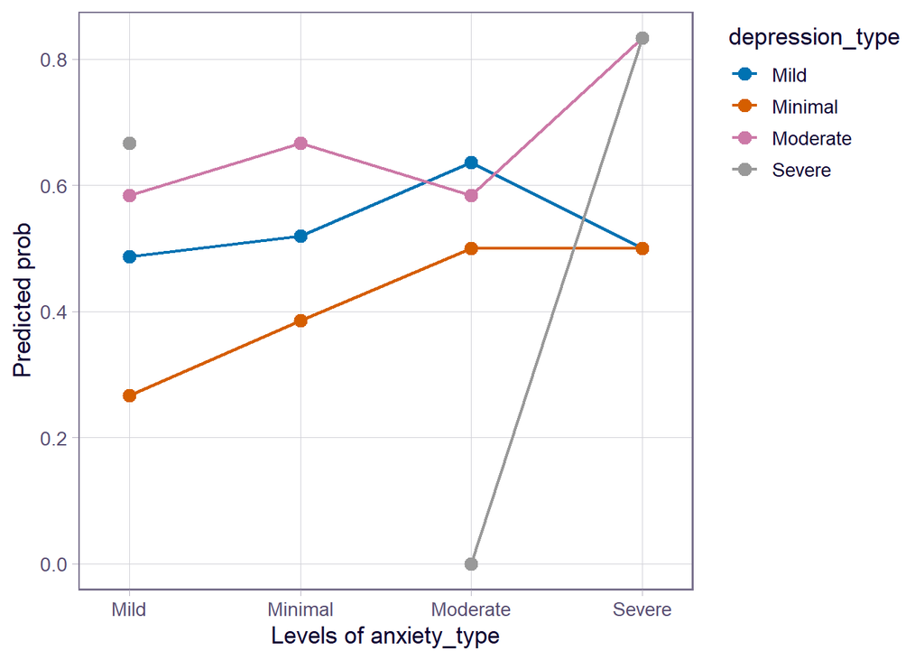

```r
check <- emmeans(glm6, ~ anxiety_type * depression_type, type = "response")
emmip(check,  depression_type ~ anxiety_type)
```

```r
glm7 <- glm(byu_resource ~ anxiety_type * depression_type, data = full_data, family = "binomial")
summary(glm7)
```

```
Call:
glm(formula = byu_resource ~ anxiety_type * depression_type,
    family = "binomial", data = full_data)

Coefficients: (1 not defined because of singularities)
                                               Estimate Std. Error z value
(Intercept)                                    -1.85630    0.48088  -3.860
anxiety_typeMinimal                            -1.32176    1.12824  -1.172
anxiety_typeModerate                           -0.44629    1.15380  -0.387
anxiety_typeSevere                            -16.70977 4612.20201  -0.004
depression_typeMinimal                         -0.78276    1.14135  -0.686
depression_typeModerate                         0.24686    0.91173   0.271
depression_typeSevere                         -16.70977 3765.84719  -0.004
anxiety_typeMinimal:depression_typeMinimal     -0.06454    1.83363  -0.035
anxiety_typeModerate:depression_typeMinimal   -15.48072 3261.31967  -0.005
anxiety_typeSevere:depression_typeMinimal       0.78276 6522.63870   0.000
anxiety_typeMinimal:depression_typeModerate   -15.63487 3765.84740  -0.004
anxiety_typeModerate:depression_typeModerate    0.44629    1.59099   0.281
anxiety_typeSevere:depression_typeModerate     -0.24686 5325.71219   0.000
anxiety_typeMinimal:depression_typeSevere            NA         NA      NA
anxiety_typeModerate:depression_typeSevere      0.44629 7531.69440   0.000
anxiety_typeSevere:depression_typeSevere       33.66640 5954.32728   0.006
                                             Pr(>|z|)
(Intercept)                                  0.000113 ***
anxiety_typeMinimal                          0.241388
anxiety_typeModerate                         0.698906
anxiety_typeSevere                           0.997109
depression_typeMinimal                       0.492827
depression_typeModerate                      0.786575
depression_typeSevere                        0.996460
anxiety_typeMinimal:depression_typeMinimal   0.971923
anxiety_typeModerate:depression_typeMinimal  0.996213
anxiety_typeSevere:depression_typeMinimal    0.999904
anxiety_typeMinimal:depression_typeModerate  0.996687
anxiety_typeModerate:depression_typeModerate 0.779087
anxiety_typeSevere:depression_typeModerate   0.999963
anxiety_typeMinimal:depression_typeSevere          NA
anxiety_typeModerate:depression_typeSevere   0.999953
anxiety_typeSevere:depression_typeSevere     0.995489
---
Signif. codes:  0 '***' 0.001 '**' 0.01 '*' 0.05 '.' 0.1 ' ' 1

(Dispersion parameter for binomial family taken to be 1)

    Null deviance: 100.869  on 195  degrees of freedom
Residual deviance:  88.856  on 181  degrees of freedom
AIC: 118.86

Number of Fisher Scoring iterations: 17
```

```r
drop1(glm7, test = "Chisq")
```

```
Single term deletions

Model:
byu_resource ~ anxiety_type * depression_type
                             Df Deviance    AIC    LRT Pr(>Chi)
<none>                            88.856 118.86
anxiety_type:depression_type  8   92.884 106.88 4.0281   0.8546
```

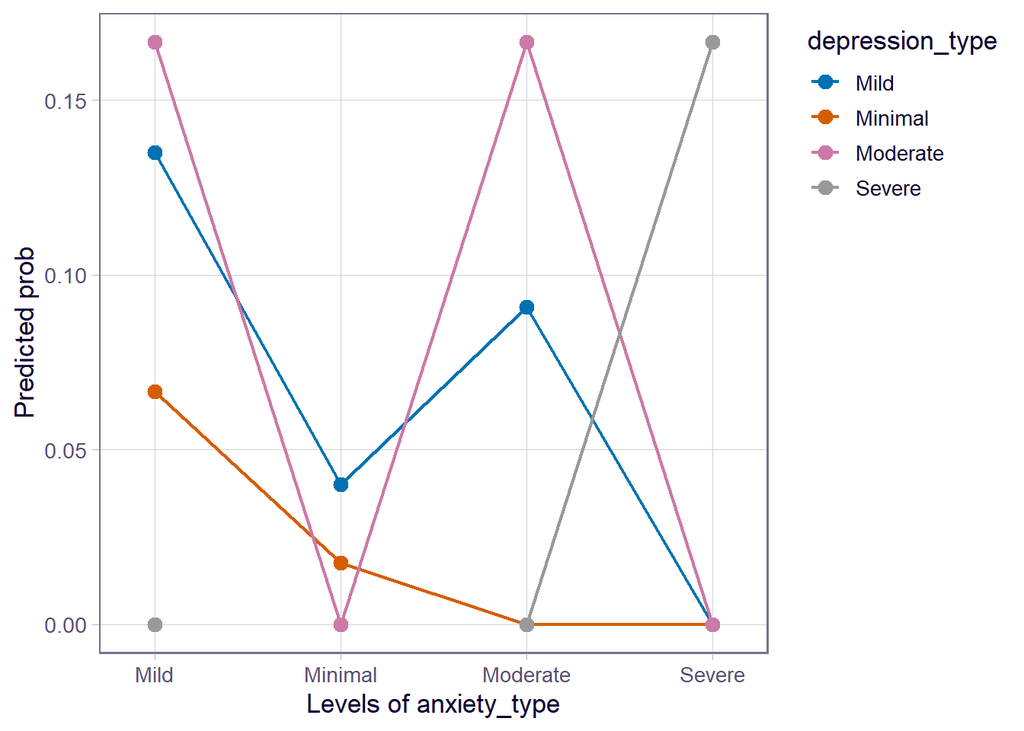

```r
check <- emmeans(glm7, ~ anxiety_type * depression_type, type = "response")
emmip(check,  depression_type ~ anxiety_type)
```

```r
glm8 <- glm(non_byu_resources ~ anxiety_type * depression_type, data = full_data, family = "binomial")
summary(glm8)
```

```
Call:
glm(formula = non_byu_resources ~ anxiety_type * depression_type,
    family = "binomial", data = full_data)

Coefficients: (1 not defined because of singularities)
                                              Estimate Std. Error z value
(Intercept)                                   -0.38299    0.33485  -1.144
anxiety_typeMinimal                            0.30295    0.52190   0.580
anxiety_typeModerate                           0.56531    0.69194   0.817
anxiety_typeSevere                             0.38299    1.45331   0.264
depression_typeMinimal                        -1.00330    0.72718  -1.380
depression_typeModerate                        0.04652    0.67452   0.069
depression_typeSevere                          1.07614    1.26969   0.848
anxiety_typeMinimal:depression_typeMinimal     0.54435    0.87432   0.623
anxiety_typeModerate:depression_typeMinimal    0.82098    1.37676   0.596
anxiety_typeSevere:depression_typeMinimal      1.00330    2.12809   0.471
anxiety_typeMinimal:depression_typeModerate    0.72667    1.45438   0.500
anxiety_typeModerate:depression_typeModerate  -0.56531    1.07912  -0.524
anxiety_typeSevere:depression_typeModerate     1.56292    1.91180   0.818
anxiety_typeMinimal:depression_typeSevere           NA         NA      NA
anxiety_typeModerate:depression_typeSevere   -15.82453  882.74450  -0.018
anxiety_typeSevere:depression_typeSevere      -0.38299    2.08857  -0.183
                                             Pr(>|z|)
(Intercept)                                     0.253
anxiety_typeMinimal                             0.562
anxiety_typeModerate                            0.414
anxiety_typeSevere                              0.792
depression_typeMinimal                          0.168
depression_typeModerate                         0.945
depression_typeSevere                           0.397
anxiety_typeMinimal:depression_typeMinimal      0.534
anxiety_typeModerate:depression_typeMinimal     0.551
anxiety_typeSevere:depression_typeMinimal       0.637
anxiety_typeMinimal:depression_typeModerate     0.617
anxiety_typeModerate:depression_typeModerate    0.600
anxiety_typeSevere:depression_typeModerate      0.414
anxiety_typeMinimal:depression_typeSevere          NA
anxiety_typeModerate:depression_typeSevere      0.986
anxiety_typeSevere:depression_typeSevere        0.855

(Dispersion parameter for binomial family taken to be 1)

    Null deviance: 267.70  on 195  degrees of freedom
Residual deviance: 254.15  on 181  degrees of freedom
AIC: 284.15

Number of Fisher Scoring iterations: 13
```

```r
drop1(glm8, test = "Chisq")
```

```
Single term deletions

Model:
non_byu_resources ~ anxiety_type * depression_type
                             Df Deviance    AIC    LRT Pr(>Chi)
<none>                            254.15 284.15
anxiety_type:depression_type  8   258.84 272.84 4.6966   0.7895
```

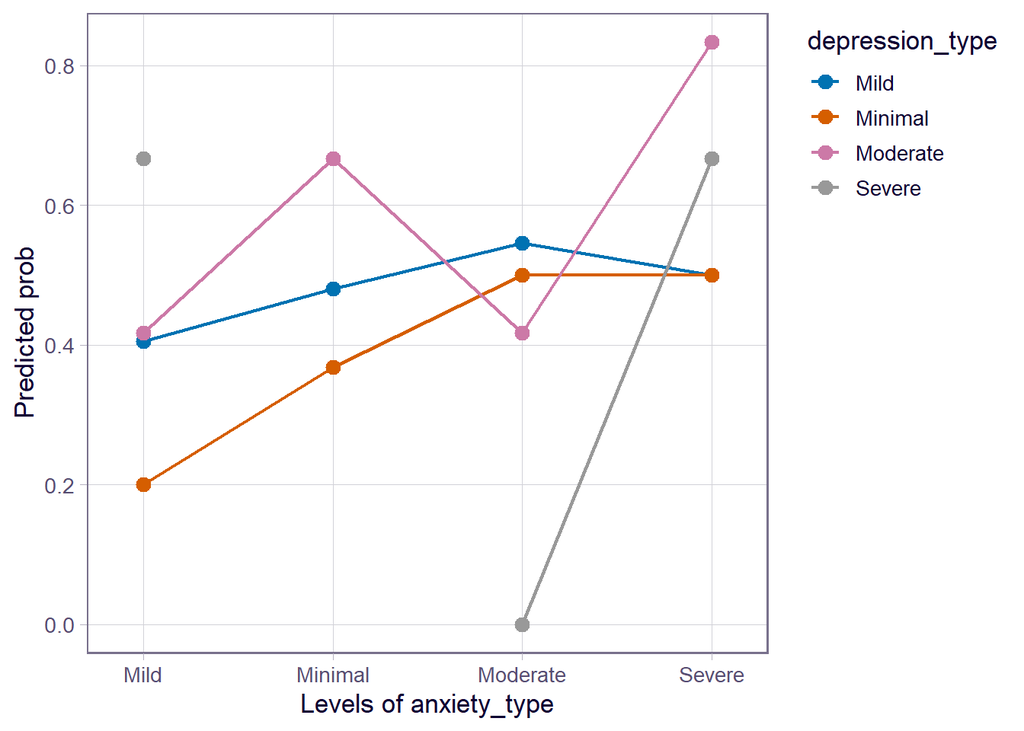

```r
check <- emmeans(glm8, ~ anxiety_type * depression_type, type = "response")
emmip(check,  depression_type ~ anxiety_type)
```

```r
# table(full_data$anxiety_type, full_data$depression_type, full_data$byu_resource)

# full_data$combo <- interaction(full_data$anxiety_type, full_data$depression_type)
# table(full_data$combo, full_data$byu_resource)

# table(full_data$anxiety_type, full_data$depression_type, full_data$non_byu_resources)

# full_data$combo <- interaction(full_data$anxiety_type, full_data$depression_type)
# table(full_data$combo, full_data$non_byu_resources)

# table(full_data$anxiety_type, full_data$depression_type, full_data$used_resource)

# full_data$combo <- interaction(full_data$anxiety_type, full_data$depression_type)
# table(full_data$combo, full_data$used_resource)
```